# Analysis of Takeda’s Studies in the AACT Database

Meera Y. Patel, M.D.

2021-01-18

The AACT database available through ClinicalTrials.gov is used for this analysis. Version 2021-01-17 is used for this analysis.

```r
library(tidyverse)
library(pg13)
library(ggplot2)
```

Clinical Trials associated with Takeda are queried by searching for the phrase “Takeda” in the “acronym”, “brief_title”, “official_title”, “source”, “limitations_and_caveats”, “why_stopped”, “ipd_access_criteria”, “ipd_url”, and “plan_to_share_ipd_description” fields in the CTGOV.STUDIES Table.

```r
conn <- local_connect("aact")

studies_fields <-
ls_fields(conn = conn,
          schema = "ctgov",
          table = "studies")

takeda_studies <- list()
for (i in seq_along(studies_fields)) {
  studies_field <- studies_fields[i]
  sql_statement <-
  SqlRender::render(
    "SELECT *
    FROM ctgov.studies s
    WHERE LOWER(s.@studies_field::varchar) LIKE LOWER('%Takeda%')",
    studies_field = studies_field
  )
  takeda_studies[[i]] <-
    query(conn = conn,
          sql_statement = sql_statement)
  names(takeda_studies)[i] <- studies_field
}

dc(conn = conn)

takeda_studies2 <-
  takeda_studies %>%
  bind_rows() %>%
  distinct()
```

The “overall_status” describes the stage of a trial’s execution and provides a glimpse into the overall clinical trial activity at Takeda.

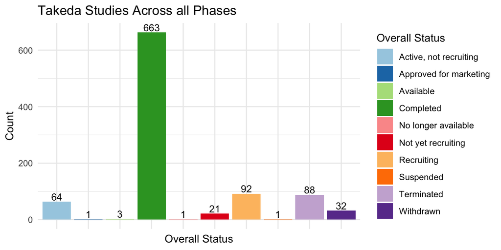

```r
ggplot(data =
         takeda_studies2 %>%
           count(overall_status) %>%
           rename(`Overall Status` = overall_status,
                  Count = n),
      mapping = aes(x = `Overall Status`,
                    y = Count,
                    fill = `Overall Status`,
                    label = Count)) +
  geom_col() +
  theme_minimal() +
  labs(title = "Takeda Studies Across all Phases") +
  scale_fill_brewer(palette = "Paired") +
  theme(axis.text.x = element_blank()) +
  geom_text(aes(label=Count), vjust=-0.2, color="black", size=3.5)
```

“Active Statuses” are statuses that are potential targets for ongoing data cleaning efforts before the study is closed and the database is locked. Here, it is arbitrarily defined as those with overall status of “Active, not recruiting”, “Available”, and “Recruiting”.

The total actual or anticipated enrollment is calculated For all studies that are active according to the definition above. This calculation gives an idea of the total number of patients that are covered by a data visualization tool like Platypus.

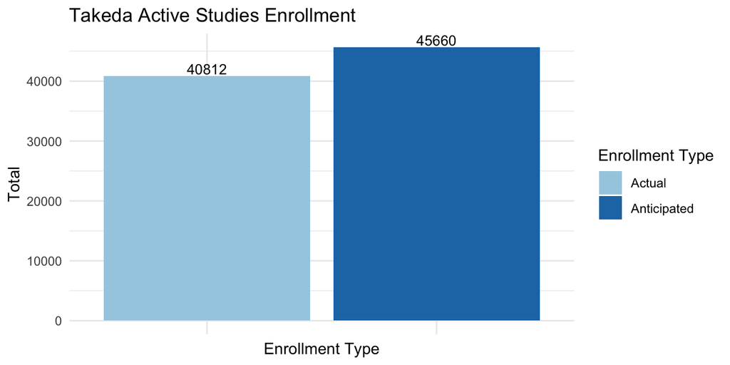

```r
active_statuses <- c("Active, not recruiting",
                     "Available",
                     "Recruiting")

takeda_studies3 <-
  takeda_studies2 %>%
  filter(overall_status %in% active_statuses)

ggplot(data =
         takeda_studies3 %>%
         filter(!is.na(enrollment_type)) %>%
         group_by(enrollment_type) %>%
         summarize(total = sum(enrollment)) %>%
         rename(`Enrollment Type` = enrollment_type,
                `Total` = total),
       mapping = aes(x = `Enrollment Type`,
                     y = Total,
                     fill = `Enrollment Type`,
                     label = Total)) +
  geom_col() +
  theme_minimal() +
  labs(title = "Takeda Active Studies Enrollment") +
  scale_fill_brewer(palette = "Paired") +
  theme(axis.text.x = element_blank()) +
  geom_text(aes(label=Total), vjust=-0.2, color="black", size=3.5)
```

Since each study can be in various phases, which would require different degree of medical review, the active studies are further broken down by phase. Non-interventional studies are summarized by subtypes “Observational”, “Observational [Patient Registry]”, and “Expanded Access”.

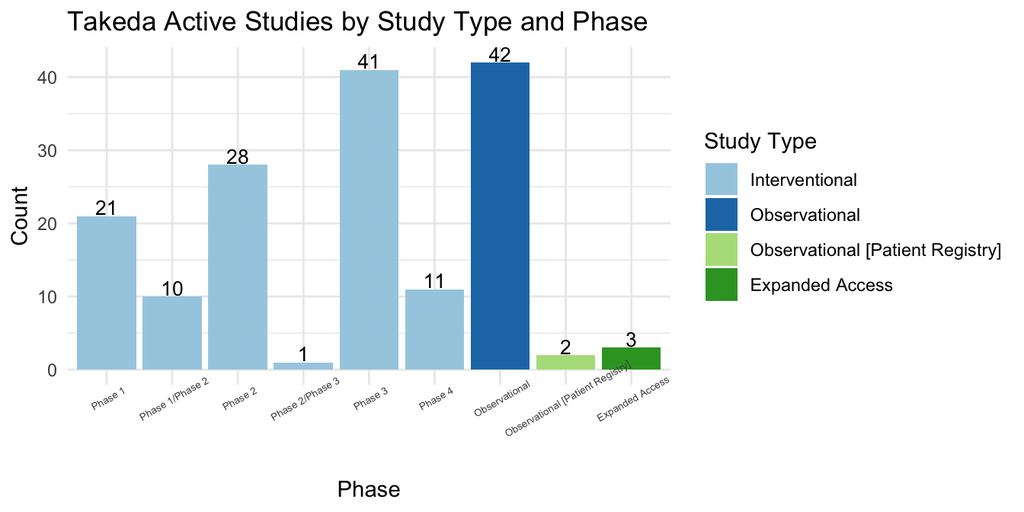

```r
takeda_studies4 <-
  takeda_studies3 %>%
  mutate(phase = coalesce(phase, study_type)) %>%
  mutate(phase = factor(phase,
                        levels = c("Phase 1",
                                   "Phase 1/Phase 2",
                                   "Phase 2",
                                   "Phase 2/Phase 3",
                                   "Phase 3",
                                   "Phase 4",
                                   "Observational",
                                   "Observational [Patient Registry]",
                                   "Expanded Access"))) %>%
  mutate(study_type = factor(study_type,
                             levels =
                               c("Interventional",
                                 "Observational",
                                 "Observational [Patient Registry]",
                                 "Expanded Access")))

ggplot(data =
         takeda_studies4 %>%
         group_by(phase) %>%
         mutate(n = length(phase)) %>%
         ungroup() %>%
         distinct(Phase = phase,
                Count = n,
                `Study Type` = study_type),
       mapping = aes(x = Phase,
                     y = Count,
                     fill = `Study Type`,
                     label = Count)) +
  geom_bar(stat = "identity") +
  theme_minimal() +
  labs(title = "Takeda Active Studies by Study Type and Phase") +
  scale_fill_brewer(palette = "Paired") +
  theme(axis.text.x = element_text(angle = 30, size = 5)) +
  geom_text(color="black", size=3.5, vjust=-0.1)
```

Since each new study could mean a new Platypus project, the total number of new studies by year, grouped by phase, are calculated.

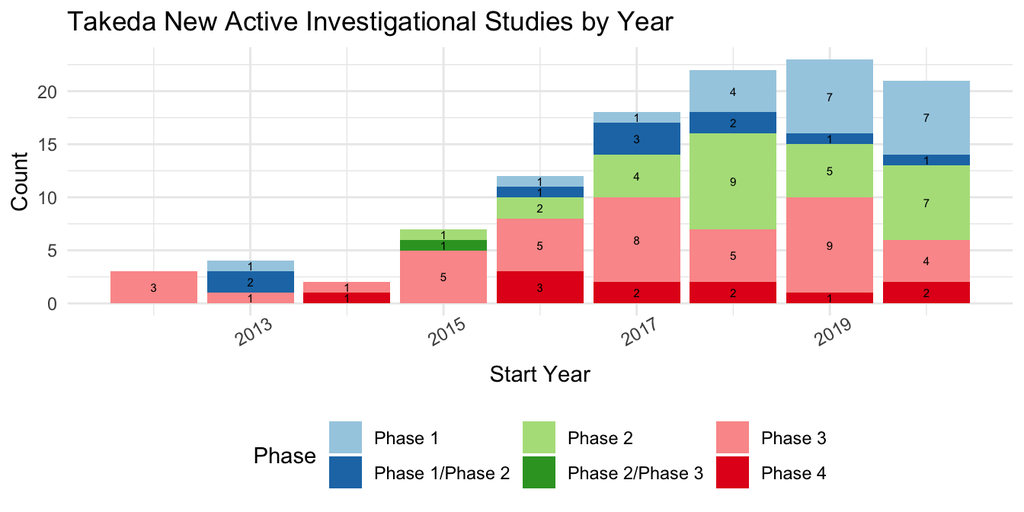

```r
ggplot(data =
         takeda_studies4 %>%
         rubix::filter_at_grepl(col = phase,
                                grepl_phrase = "Phase",
                                ignore.case = FALSE) %>%
         mutate(start_year = lubridate::year(start_date)) %>%
         group_by(phase,start_year) %>%
         mutate(n = length(phase)) %>%
         ungroup() %>%
         distinct(Phase = phase,
                `Start Year` = start_year,
                Count = n),
       mapping = aes(x = `Start Year`,
                     y = Count,
                     fill = Phase,
                     label = Count)) +
  geom_col() +
  theme_minimal() +
  labs(title = "Takeda New Active Investigational Studies by Year") +
  scale_fill_brewer(palette = "Paired") +
  theme(axis.text.x = element_text(angle = 30),
        legend.position = "bottom") +
  geom_text(size = 2,
            position = position_stack(vjust = 0.5))
```

Conversely, each completed study could mean either a bump in workload (activities to close a database) and/or a removal of a project from the Platypus portfolio. The number of completed studies by year, grouped by phase, is calculated.

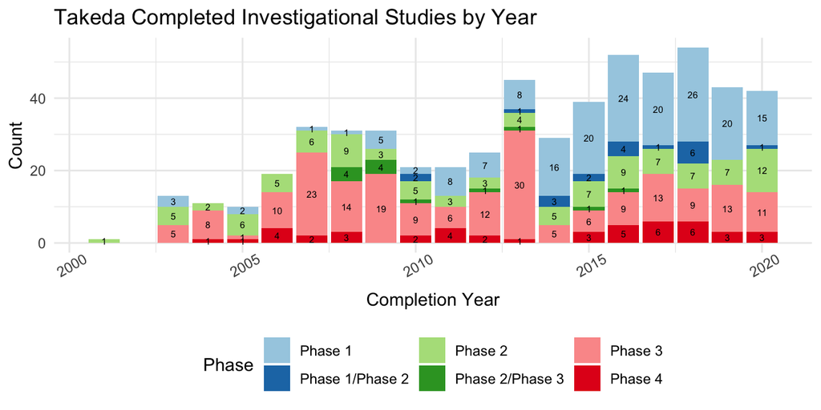

```r
ggplot(data =
         takeda_studies2 %>%
         rubix::filter_at_grepl(col = phase,
                                grepl_phrase = "Phase",
                                ignore.case = FALSE) %>%
         filter(overall_status %in% c("Completed")) %>%
         mutate(completion_year = lubridate::year(completion_date)) %>%
         group_by(phase,completion_year) %>%
         mutate(n = length(phase)) %>%
         ungroup() %>%
         distinct(Phase = phase,
                `Completion Year` = completion_year,
                Count = n),
       mapping = aes(x = `Completion Year`,
                     y = Count,
                     fill = Phase,
                     label = Count)) +
  geom_col() +
  theme_minimal() +
  labs(title = "Takeda Completed Investigational Studies by Year") +
  scale_fill_brewer(palette = "Paired") +
  theme(axis.text.x = element_text(angle = 30),
        legend.position = "bottom")  +
  geom_text(size = 2,
            position = position_stack(vjust = 0.5))
```

I also want to see the distribution of study length from start to completion by phase. This would translate into the length of time a given study would be in the Platypus portfolio as it is being monitored for medical review.

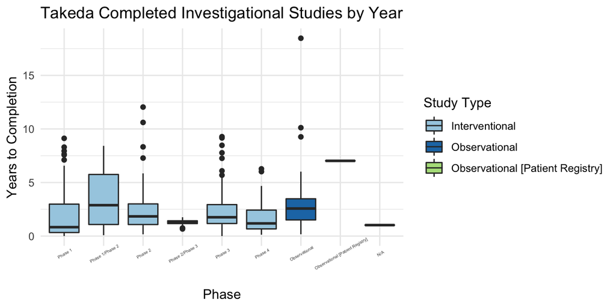

```r
ggplot(data =
         takeda_studies2 %>%
         mutate(phase = coalesce(phase, study_type)) %>%
        mutate(phase = factor(phase,
                              levels = c("Phase 1",
                                         "Phase 1/Phase 2",
                                         "Phase 2",
                                         "Phase 2/Phase 3",
                                         "Phase 3",
                                         "Phase 4",
                                         "Observational",
                                         "Observational [Patient Registry]",
                                         "Expanded Access",
                                         "N/A"))) %>%
        mutate(study_type = factor(study_type,
                                   levels =
                                     c("Interventional",
                                       "Observational",
                                       "Observational [Patient Registry]",
                                       "Expanded Access"))) %>%
         filter(overall_status %in% c("Completed")) %>%
         mutate(years_to_complete = (as.numeric(difftime(completion_date,
                                             start_date,
                                             units = "weeks")))/52) %>%
         distinct(Phase = phase,
                  `Study Type` = study_type,
                  `Years to Completion` = years_to_complete),
       mapping = aes(x = Phase,
                     y = `Years to Completion`,
                     group = Phase,
                     fill = `Study Type`)) +
  geom_boxplot() +
  theme_minimal() +
  labs(title = "Takeda Completed Investigational Studies by Year",
       y = "Years to Completion") +
  scale_fill_brewer(palette = "Paired") +
  theme(axis.text.x = element_text(angle = 30,size = 3.5),
        legend.position = "right")
```

Since the study time length is a common topic of discussion, the analysis above is repeated with all completed studies in the AACT database that started on or after 01-01-1990.

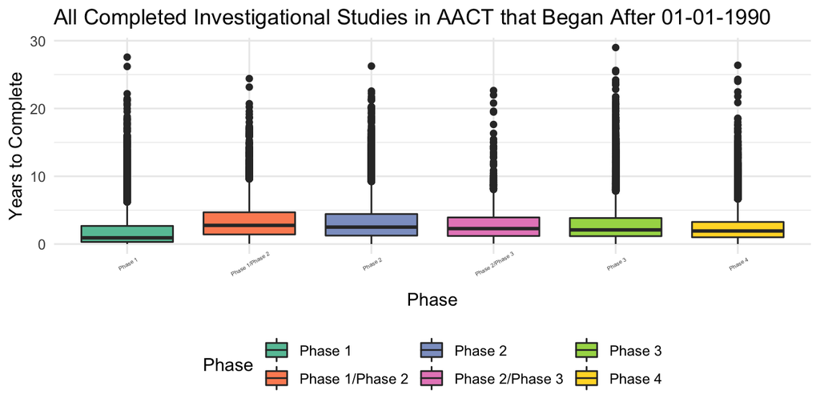

```r
ggplot(data =
         all_data %>%
         filter(start_date > as.Date("1990-01-01")) %>%
         filter(completion_date > start_date) %>%
         mutate(years_to_complete = (as.numeric(difftime(completion_date,
                                                         start_date,
                                                         units = "weeks")))/52) %>%
         mutate(phase = coalesce(phase, study_type)) %>%
         rubix::filter_at_grepl(col = phase,
                                grepl_phrase = "^Phase") %>%
         distinct(nct_id,
                  Phase = phase,
                  `Years to Completion` = years_to_complete,
                  `Study Type` = study_type),
       mapping = aes(x = Phase,
                     y = `Years to Completion`,
                     group = Phase,
                     fill = Phase)) +
  geom_boxplot() +
  theme_minimal() +
  labs(title = "All Completed Investigational Studies in AACT that Began After 01-01-1990",
       y = "Years to Complete") +
  scale_fill_brewer(palette = "Set2") +
  theme(axis.text.x = element_text(angle = 30, size = 3.5),
        legend.position = "bottom")
```

A work by [Meera Y. Patel](https://github.com/meerapatelmd/)

*patelmeeray@gmail.com*